# Joins and `tidyr` Homework

The data for the joining tasks is from [Kaggle](https://www.kaggle.com/ananta/credit-card-data) and contains synthetic (fake) credit card information and transactions. The data for the `tidyr` tasks is also synthetic.

# 1 MVP

## 1.1 Joins

**Question 1**

Read in all 4 credit card transaction datasets and clean column names.

```r
library(tidyverse)
library(janitor)
card_base <- read_csv("data/CardBase.csv") %>%
  clean_names()
customer_base <- read_csv("data/CustomerBase.csv") %>%
  clean_names()
fraud_base <- read_csv("data/FraudBase.csv") %>%
  clean_names()
transaction_base <- read_csv("data/TransactionBase.csv") %>%
  clean_names()
card_base
```

| card_number | card_family | credit_limit | cust_id |
| --- | --- | --- | --- |
| 8638-5407-3631-8196 | Premium | 530000 | CC67088 |
| 7106-4239-7093-1515 | Gold | 18000 | CC12076 |
| 6492-5655-8241-3530 | Premium | 596000 | CC97173 |
| 2868-5606-5152-5706 | Gold | 27000 | CC55858 |
| 1438-6906-2509-8219 | Platinum | 142000 | CC90518 |
| 2764-7023-8396-5255 | Gold | 50000 | CC49168 |
| 4864-7119-5608-7611 | Premium | 781000 | CC66746 |
| 5160-8427-6529-3274 | Premium | 490000 | CC28930 |
| 6691-5105-1556-4131 | Premium | 640000 | CC76766 |
| 1481-2536-2178-7547 | Premium | 653000 | CC18007 |

[output cut: 490 more lines]

```r
customer_base
```

| cust_id | age | customer_segment | customer_vintage_group |
| --- | --- | --- | --- |
| CC25034 | 35 | Diamond | VG1 |
| CC59625 | 22 | Diamond | VG1 |
| CC69314 | 33 | Diamond | VG1 |
| CC67036 | 46 | Diamond | VG1 |
| CC25597 | 44 | Diamond | VG1 |
| CC57469 | 22 | Diamond | VG1 |
| CC15926 | 50 | Diamond | VG1 |
| CC31951 | 46 | Diamond | VG1 |
| CC32388 | 26 | Diamond | VG1 |
| CC48802 | 44 | Diamond | VG1 |

[output cut: 5664 more lines]

```r
fraud_base
```

| transaction_id | fraud_flag |
| --- | --- |
| CTID50558449 | 1 |
| CTID55936882 | 1 |
| CTID63762180 | 1 |
| CTID76723439 | 1 |
| CTID21246201 | 1 |
| CTID26555772 | 1 |
| CTID20567160 | 1 |
| CTID54759604 | 1 |
| CTID44626561 | 1 |
| CTID73773088 | 1 |

[output cut: 99 more lines]

```r
transaction_base
```

| transaction_id | transaction_date | credit_card_id | transaction_value | transaction_segment |
| --- | --- | --- | --- | --- |
| CTID28830551 | 24-Apr-16 | 1629-9566-3285-2123 | 23649 | SEG25 |
| CTID45504917 | 11-Feb-16 | 3697-6001-4909-5350 | 26726 | SEG16 |
| CTID47312290 | 1-Nov-16 | 5864-4475-3659-1440 | 22012 | SEG14 |
| CTID25637718 | 28-Jan-16 | 5991-4421-8476-3804 | 37637 | SEG17 |
| CTID66743960 | 17-Mar-16 | 1893-8853-9900-8478 | 5113 | SEG14 |
| CTID22308010 | 15-May-16 | 5206-5979-9383-4538 | 9551 | SEG13 |
| CTID41917614 | 11-Jul-16 | 5129-6974-6371-2964 | 29511 | SEG13 |
| CTID24523483 | 26-Jul-16 | 9930-4634-8565-6716 | 27830 | SEG21 |
| CTID59109135 | 16-Jan-16 | 4092-8604-7363-3393 | 35328 | SEG18 |
| CTID62465865 | 6-Nov-16 | 3594-2190-6052-1265 | 9567 | SEG21 |

[output cut: 9990 more lines]

**Question 2**

Join the data containing card details and customer details by customer id, so that all records of card details and any matching records in customer details are kept. Before you run the code, think about how many rows you expect to see after joining.

```r
customer_card_details <- card_base %>%
  left_join(
    customer_base, "cust_id")

customer_card_details
```

| card_number | card_family | credit_limit | cust_id | age | customer_segment | customer_vintage_group |
| --- | --- | --- | --- | --- | --- | --- |
| 8638-5407-3631-8196 | Premium | 530000 | CC67088 | 27 | Diamond | VG1 |
| 7106-4239-7093-1515 | Gold | 18000 | CC12076 | 48 | Gold | VG3 |
| 6492-5655-8241-3530 | Premium | 596000 | CC97173 | 22 | Diamond | VG1 |
| 2868-5606-5152-5706 | Gold | 27000 | CC55858 | 30 | Diamond | VG1 |
| 1438-6906-2509-8219 | Platinum | 142000 | CC90518 | 50 | Platinum | VG2 |
| 2764-7023-8396-5255 | Gold | 50000 | CC49168 | 22 | Gold | VG3 |
| 4864-7119-5608-7611 | Premium | 781000 | CC66746 | 44 | Diamond | VG1 |
| 5160-8427-6529-3274 | Premium | 490000 | CC28930 | 22 | Platinum | VG2 |
| 6691-5105-1556-4131 | Premium | 640000 | CC76766 | 33 | Platinum | VG2 |
| 1481-2536-2178-7547 | Premium | 653000 | CC18007 | 20 | Diamond | VG1 |

[output cut: 490 more lines]

**Question 3**

Join the data containing fraud details with transaction details so all rows of both tables are kept. What does the resulting row number tell you?

```r
fraud_and_transaction <- fraud_base %>%
  full_join(
    transaction_base,
    by="transaction_id")

fraud_and_transaction
```

| transaction_id | fraud_flag | transaction_date | credit_card_id | transaction_value | transaction_segment |
| --- | --- | --- | --- | --- | --- |
| CTID50558449 | 1 | 6-May-16 | 4246-1369-3659-8804 | 6984 | SEG23 |
| CTID55936882 | 1 | 29-Nov-16 | 1336-9200-1264-2551 | 34367 | SEG21 |
| CTID63762180 | 1 | 5-Dec-16 | 8528-6154-7390-5081 | 44550 | SEG15 |
| CTID76723439 | 1 | 15-Sep-16 | 7908-2695-7391-7499 | 48275 | SEG16 |
| CTID21246201 | 1 | 29-Feb-16 | 2524-4184-5908-6750 | 35751 | SEG25 |
| CTID26555772 | 1 | 11-Jan-16 | 5734-5619-8469-4044 | 683 | SEG22 |
| CTID20567160 | 1 | 8-Oct-16 | 3295-6390-4452-7199 | 49155 | SEG16 |
| CTID54759604 | 1 | 7-Sep-16 | 8262-8743-6406-7105 | 48567 | SEG20 |
| CTID44626561 | 1 | 20-Feb-16 | 6321-2048-7733-8765 | 12894 | SEG14 |
| CTID73773088 | 1 | 30-Mar-16 | 1661-3809-5334-2155 | 8060 | SEG21 |

[output cut: 9990 more lines]

The resulting row number confirms all transaction_id are present as this is the row number we see in transaction_base dataset that we originally pulled. The fraud_flag is displaying NAs where the data doesn’t match across the two datasets.

**Question 4**

Join the data containing card details with transaction details so rows from the first which have matching ones in the second are returned, but only return rows in the first table once.

```r
card_details_with_transaction <-
  card_base %>%
  semi_join(transaction_base,
            by= c("card_number" = "credit_card_id"))

card_details_with_transaction
```

| card_number | card_family | credit_limit | cust_id |
| --- | --- | --- | --- |
| 8638-5407-3631-8196 | Premium | 530000 | CC67088 |
| 7106-4239-7093-1515 | Gold | 18000 | CC12076 |
| 6492-5655-8241-3530 | Premium | 596000 | CC97173 |
| 2868-5606-5152-5706 | Gold | 27000 | CC55858 |
| 1438-6906-2509-8219 | Platinum | 142000 | CC90518 |
| 2764-7023-8396-5255 | Gold | 50000 | CC49168 |
| 4864-7119-5608-7611 | Premium | 781000 | CC66746 |
| 5160-8427-6529-3274 | Premium | 490000 | CC28930 |
| 6691-5105-1556-4131 | Premium | 640000 | CC76766 |
| 1481-2536-2178-7547 | Premium | 653000 | CC18007 |

[output cut: 490 more lines]

## 1.2 `tidyr`

**Question 5**

Read in `hat_observations` and separate `observation` into two columns, `hat_colour` and `hat_type`.

```r
hat_observations <- read_csv("data/hat_observations.csv")
hat_observations <- hat_observations %>%
  separate(observation, c("hat_colour", "hat_type"),
           sep = "," )

hat_observations
```

| day | month | year | hat_colour | hat_type | observation_count |
| --- | --- | --- | --- | --- | --- |
| 25 | 10 | 2019 | black | beret | 7 |
| 11 | 9 | 2019 | blue | top hat | 10 |
| 4 | 12 | 2018 | green | santa hat | 9 |
| 18 | 6 | 2018 | white | beret | 9 |
| 26 | 9 | 2018 | black | santa hat | 1 |
| 13 | 12 | 2018 | red | santa hat | 6 |
| 7 | 12 | 2019 | yellow | beret | 5 |
| 26 | 5 | 2018 | black | beret | 6 |
| 26 | 8 | 2018 | multicoloured | top hat | 4 |
| 12 | 6 | 2018 | purple | beanie | 10 |

[output cut: 90 more lines]

**Question 6**

```r
hat_observations <- hat_observations %>%
  unite(date, c("day", "month", "year"), sep ="/")

hat_observations
```

| date | hat_colour | hat_type | observation_count |
| --- | --- | --- | --- |
| 25/10/2019 | black | beret | 7 |
| 11/9/2019 | blue | top hat | 10 |
| 4/12/2018 | green | santa hat | 9 |
| 18/6/2018 | white | beret | 9 |
| 26/9/2018 | black | santa hat | 1 |
| 13/12/2018 | red | santa hat | 6 |
| 7/12/2019 | yellow | beret | 5 |
| 26/5/2018 | black | beret | 6 |
| 26/8/2018 | multicoloured | top hat | 4 |
| 12/6/2018 | purple | beanie | 10 |

[output cut: 90 more lines]

# 2 Extension

## 2.1 Joins

**Question 1**

Can you join all 4 datasets together so that you’re left with a dataset that looks like below with **109 rows** and **12 columns**?

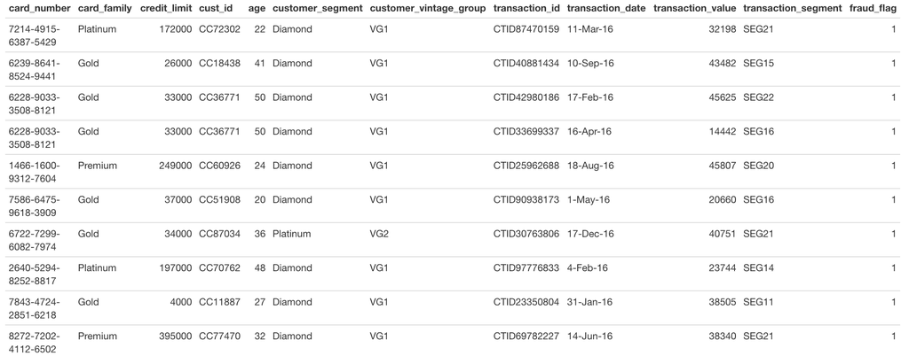

```r
all_joined <- customer_card_details%>%
  left_join(
    transaction_base,
    by= c("card_number" = "credit_card_id")) %>%
  right_join(
    fraud_base,
    by = "transaction_id"
  )

all_joined
```

| card_number | card_family | credit_limit | cust_id | age | customer_segment | customer_vintage_group | transaction_id | transaction_date | transaction_value | transaction_segment | fraud_flag |
| --- | --- | --- | --- | --- | --- | --- | --- | --- | --- | --- | --- |
| 7214-4915-6387-5429 | Platinum | 172000 | CC72302 | 22 | Diamond | VG1 | CTID87470159 | 11-Mar-16 | 32198 | SEG21 | 1 |
| 6239-8641-8524-9441 | Gold | 26000 | CC18438 | 41 | Diamond | VG1 | CTID40881434 | 10-Sep-16 | 43482 | SEG15 | 1 |
| 6228-9033-3508-8121 | Gold | 33000 | CC36771 | 50 | Diamond | VG1 | CTID42980186 | 17-Feb-16 | 45625 | SEG22 | 1 |
| 6228-9033-3508-8121 | Gold | 33000 | CC36771 | 50 | Diamond | VG1 | CTID33699337 | 16-Apr-16 | 14442 | SEG16 | 1 |
| 1466-1600-9312-7604 | Premium | 249000 | CC60926 | 24 | Diamond | VG1 | CTID25962688 | 18-Aug-16 | 45807 | SEG20 | 1 |
| 7586-6475-9618-3909 | Gold | 37000 | CC51908 | 20 | Diamond | VG1 | CTID90938173 | 1-May-16 | 20660 | SEG16 | 1 |
| 6722-7299-6082-7974 | Gold | 34000 | CC87034 | 36 | Platinum | VG2 | CTID30763806 | 17-Dec-16 | 40751 | SEG21 | 1 |
| 2640-5294-8252-8817 | Platinum | 197000 | CC70762 | 48 | Diamond | VG1 | CTID97776833 | 4-Feb-16 | 23744 | SEG14 | 1 |
| 7843-4724-2851-6218 | Gold | 4000 | CC11887 | 27 | Diamond | VG1 | CTID23350804 | 31-Jan-16 | 38505 | SEG11 | 1 |
| 8272-7202-4112-6502 | Premium | 395000 | CC77470 | 32 | Diamond | VG1 | CTID69782227 | 14-Jun-16 | 38340 | SEG21 | 1 |

[output cut: 99 more lines]

## 2.2 `tidyr`

**Question 2**

Read in `exam_scores` and transform it into long format with two new columns `exam_question` and `score`. Then, using `separate` and `select`, remove superfluous information from the values in `exam_question`

```r
exam_scores <- read_csv("data/exam_scores.csv")
exams_long <- exam_scores %>%
  pivot_longer(cols = starts_with("Exam"),
               names_to = "exam_question",
               values_to = "score")
exams_long
```

| id | exam_question | score |
| --- | --- | --- |
| 1 | exam_Q1 | 69 |
| 1 | exam_Q2 | 59 |
| 1 | exam_Q3 | 95 |
| 1 | exam_Q4 | 56 |
| 1 | exam_Q5 | 54 |
| 1 | exam_Q6 | 78 |
| 1 | exam_Q7 | 86 |
| 1 | exam_Q8 | 99 |
| 1 | exam_Q9 | 34 |
| 1 | exam_Q10 | 47 |

[output cut: 1990 more lines]

```r
exams_tidy <- exams_long %>%
  separate(exam_question,
           c("text", "question"),
           sep = "_Q" ) %>%
  select(id, question, score)

exams_tidy
```

| id | question | score |
| --- | --- | --- |
| 1 | 1 | 69 |
| 1 | 2 | 59 |
| 1 | 3 | 95 |
| 1 | 4 | 56 |
| 1 | 5 | 54 |
| 1 | 6 | 78 |
| 1 | 7 | 86 |
| 1 | 8 | 99 |
| 1 | 9 | 34 |
| 1 | 10 | 47 |

[output cut: 1990 more lines]